## Geopolitical risk, WGI, and the real exchange rate

ECON 4999B

# Geopolitical risk, WGI, and the real exchange rate

**Capital-flow volatility and the export channel**

Research presentation  
November 2026

## Definition of Geopolitical Risk, Institutional Quality and Exchange Rate

**Can WGI serve as a cushion for the exchange rate under geopolitical uncertainty?**

- **Geopolitical Risk**: armed conflict, terrorism, and tension between states — not general economic uncertainty
  - we will measure Geopolitical Risk with the paper uses the monthly country-specific GPR index of Caldara and Iacoviello (2022)
- **Institutional Quality**: The quality of an institution
  - we use the world governance index as a proxy of institutional quality
- **Exchange rate**: real effective exchange rate
  - we would like to capture the price movement between domestic and its trade partner

## Content

- **Motivation**
- **Transmission Channel**
  - Channel 1: How does IQ affect real effective exchange rate
  - Channel 2: How does IQ affect the volatility of real effective exchange rate via capital flow
- **Result Overview**
- **Channel Detail**
- **Conclusion**

## Motivation - Russia-Ukraine War

Kazakhstan

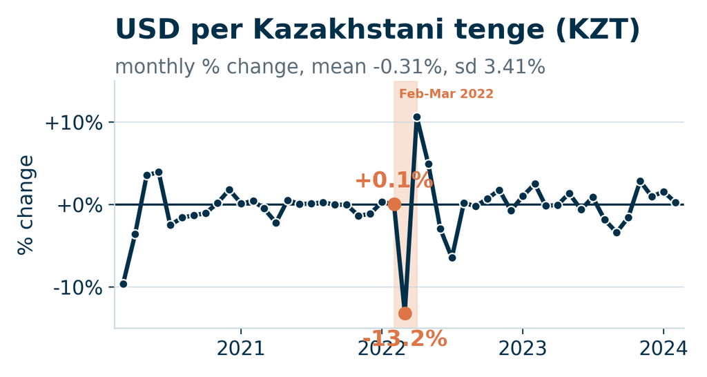

Georgia

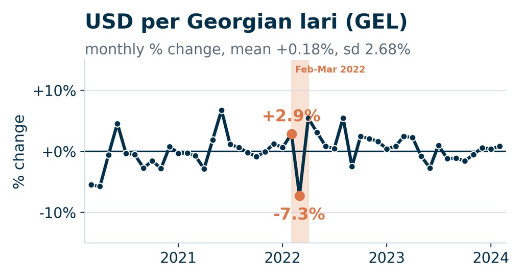

- With similar exposure to the crisis, Georgia displays a smaller decline in exchange rate
- We know that Kazakhstan has a more significant corruption issue than Georgia

**Can institutional quality explain the difference in the decline in exchange rate?**

## Channel 2: How Institutional Quality affect Capital Flow Volatility

- **Intuition: weaker institution should experience a more volatile currency**
  - We would like to rule out the possibility of managed flow such as Vietnam, therefore we will measure the vol. in capital flow instead
- **Model: extend on John Beirne model, we will include institutional quality in his model measuring how geopolitical risk affecting capital flow vol**

## Channel 1: IQ on REER (Monthly)

$$\begin{aligned}
\Delta \log REER_{i,t}={}&\beta_1 GPR_{i,t}^{z}+\beta_2 WGI_{i,t-1}+\beta_3\left(WGI_{i,t-1}\times GPR_{i,t}^{z}\right)\\
&+\gamma^{\prime}X_{i,t-1}+\delta_i+\varepsilon_{i,t}
\end{aligned}$$

$Y=\Delta \log REER_{i,t}$: monthly change in log REER | $GPR_{i,t}^{z}$: country-standardized geopolitical risk | $WGI_{i,t-1}\times GPR_{i,t}^{z}$: interaction  
$X_{i,t-1}$: lagged controls (policy rate, inflation, oil price, VIX, EPU, financial development, debt/GDP) | $\delta_i$: country fixed effect | $\varepsilon_{i,t}$: country-clustered error

|  | Voice & account. | Political stability | Gov. effectiveness | Regulatory quality | Rule of law | Control of corruption |
| --- | --- | --- | --- | --- | --- | --- |
| **WGI, lagged** | 0.0020 (0.455) | 0.0002 (0.907) | 0.0033** (0.037) | 0.0041* (0.071) | 0.0014 (0.658) | 0.0004 (0.845) |
| **GPR, standardized** | −0.0001 (0.607) | −0.0003 (0.235) | −0.0001 (0.768) | −0.0002 (0.705) | −0.0002 (0.484) | −0.0002 (0.402) |
| **WGI × GPR** | −0.0006* (0.059) | −0.0004 (0.378) | −0.0002 (0.671) | −0.0000 (0.940) | −0.0003 (0.403) | −0.0004 (0.431) |

3,315 country-months, 14 emerging economies, Feb 2002–Jan 2022. Country fixed effects; country-clustered standard errors. Each column is a separate regression on one WGI aspect. p-values in parentheses. * p<0.10, ** p<0.05, *** p<0.01.

## Channel 1: IQ on REER (Quarterly)

$$\begin{aligned}
\Delta \log REER_{i,q-1}={}&\beta_1 GPR_{i,q}^{z}+\beta_2 WGI_{i,q-1}+\beta_3\left(WGI_{i,q-1}\times GPR_{i,q}^{z}\right)\\
&+\gamma^{\prime}X_{i,q-1}+\delta_i+\varepsilon_{i,q-1}
\end{aligned}$$

$Y=\Delta \log REER_{i,q-1}$: previous quarter's change in log REER | $WGI_{i,q-1}$: institutional quality, lagged one quarter | $GPR_{i,q}^{z}$: country-standardized geopolitical risk | $WGI_{i,q-1}\times GPR_{i,q}^{z}$: interaction  
$X_{i,q-1}$: lagged controls (policy rate, inflation, oil price, VIX, EPU, financial development, debt/GDP) | $\delta_i$: country fixed effect | $\varepsilon_{i,q-1}$: country-clustered error

|  | Voice & account. | Political stability | Gov. effectiveness | Regulatory quality | Rule of law | Control of corruption |
| --- | --- | --- | --- | --- | --- | --- |
| **WGI, lagged one quarter** | 0.0057 (0.366) | 0.0002 (0.943) | 0.0111** (0.022) | 0.0149** (0.044) | 0.0027 (0.743) | 0.0062 (0.364) |
| **GPR, standardized** | −0.0013 (0.341) | −0.0010 (0.399) | −0.0011 (0.551) | −0.0024 (0.213) | −0.0014 (0.267) | −0.0016 (0.196) |
| **WGI × GPR** | 0.0014 (0.510) | 0.0013 (0.403) | −0.0010 (0.739) | 0.0028 (0.229) | 0.0016 (0.453) | 0.0025 (0.139) |

1,104 country-quarters, 14 emerging economies, 2002-Q2–2022-Q1. Country fixed effects; country-clustered standard errors. Each column is a separate regression on one WGI aspect. p-values in parentheses. * p<0.10, ** p<0.05, *** p<0.01.

- From the result above, we can only conclude that better government effectiveness and regulatory quality will have a positive effect on exchange rate
- It does not explain the cushion effect of WGI
- We will proceed to annual data

## Channel 1: IQ on REER (Annual)

$$\begin{aligned}
\Delta \log REER_{i,t}={}&\beta_1 GPR_{i,t}^{z}+\beta_2 WGI_{i,t}+\beta_3\left(WGI_{i,t}\times GPR_{i,t}^{z}\right)\\
&+\gamma^{\prime}X_{i,t}+\delta_i+\varepsilon_{i,t}
\end{aligned}$$

$Y=\Delta \log REER_{i,t}$: annual change in log REER | $WGI_{i,t}$: institutional quality, current year | $GPR_{i,t}^{z}$: country-standardized geopolitical risk | $WGI_{i,t}\times GPR_{i,t}^{z}$: interaction  
$X_{i,t}$: controls in year \(t\) (policy rate, inflation, oil price, EPU: annual change; log VIX: annual mean; financial development, debt/GDP: annual change) | $\delta_i$: country fixed effect | $\varepsilon_{i,t}$: country-clustered error

|  | Voice & account. | Political stability | Gov. effectiveness | Regulatory quality | Rule of law | Control of corruption |
| --- | --- | --- | --- | --- | --- | --- |
| **WGI, current year** | 0.0288 (0.151) | 0.0051 (0.720) | 0.0206 (0.149) | 0.0407* (0.056) | 0.0292 (0.216) | 0.0314* (0.093) |
| **GPR, standardized** | −0.0144** (0.034) | −0.0154** (0.029) | −0.0152** (0.012) | −0.0156** (0.013) | −0.0148** (0.013) | −0.0161*** (0.005) |
| **WGI × GPR** | 0.0046 (0.433) | 0.0007 (0.913) | −0.0024 (0.755) | −0.0022 (0.705) | 0.0036 (0.653) | 0.0065 (0.318) |

273 country-years, 14 emerging economies, 2002–2021. Country fixed effects; country-clustered standard errors. Each column is a separate regression on one WGI aspect. p-values in parentheses. * p<0.10, ** p<0.05, *** p<0.01.

- There is a very significant drag of GPR on REER in annual, but we do not see WGI playing any roles in this case
- We argue that the interaction variable is highly correlated with the control variable

## Channel 1 - Model 2

$$\begin{aligned}
100\times\frac{Debt_{i,t}-Debt_{i,t-1}}{Debt_{i,t-1}}={}&\beta_1 GPR_{i,t}^{z}+\beta_2 WGI_{i,t}+\beta_3\left(WGI_{i,t}\times GPR_{i,t}^{z}\right)\\
&+\delta_i+\varepsilon_{i,t}
\end{aligned}$$

$Y=100\times\dfrac{Debt_{i,t}-Debt_{i,t-1}}{Debt_{i,t-1}}$: annual percentage change in the debt-to-GDP ratio | $WGI_{i,t}$: institutional quality, current year | $GPR_{i,t}^{z}$: country-standardized geopolitical risk | $WGI_{i,t}\times GPR_{i,t}^{z}$: interaction  
No control variables in this specification | $\delta_i$: country fixed effect | $\varepsilon_{i,t}$: country-clustered error

|  | Voice & account. | Political stability | Gov. effectiveness | Regulatory quality | Rule of law | Control of corruption |
| --- | --- | --- | --- | --- | --- | --- |
| **WGI, current year** | −2.2838 (0.683) | 1.5275 (0.605) | 10.5196** (0.018) | −5.3002 (0.461) | −5.9823 (0.419) | 1.2289 (0.826) |
| **GPR, standardized** | −2.5231 (0.206) | −6.1566*** (0.000) | 0.0107 (0.996) | −0.7815 (0.755) | −3.7721** (0.011) | −3.1792** (0.030) |
| **WGI × GPR** | −5.1592** (0.025) | −5.9701*** (0.003) | −10.0958** (0.011) | −6.9492* (0.060) | −6.1564** (0.046) | −4.9981 (0.178) |

300 country-years, 15 emerging economies, 2002–2021. Country fixed effects; country-clustered standard errors. Each column is a separate regression on one WGI aspect. p-values in parentheses. * p<0.10, ** p<0.05, *** p<0.01.

- We can see that there is a significance in the interaction variable and GPR, but the result we have is not economically intuitive
- We argue that debt to GDP ratio only capture the public debt, the effect should be reflected in the private sector, therefore we measure capital flow which capture the private sector flow

## Channel 1 - Model 3

$$\begin{aligned}
CF_{i,q}={}&\beta_1 GPR_{i,q}^{z}+\beta_2 WGI_{i,q-1}+\beta_3\left(WGI_{i,q-1}\times GPR_{i,q}^{z}\right)\\
&+\gamma^{\prime}X_{i,q-1}+\delta_i+\varepsilon_{i,q}
\end{aligned}$$

$Y=CF_{i,q}$: quarterly capital flow, first stage | $WGI_{i,q-1}$: institutional quality, lagged one quarter | $GPR_{i,q}^{z}$: standardized geopolitical risk | $WGI_{i,q-1}\times GPR_{i,q}^{z}$: interaction  
$X_{i,q-1}$: lagged controls | $\delta_i$: country fixed effect | $\varepsilon_{i,q}$: country-clustered error

|  | Voice & account. | Political stability | Gov. effectiveness | Regulatory quality | Rule of law | Control of corruption |
| --- | --- | --- | --- | --- | --- | --- |
| **WGI, lagged one quarter** | −4604.59** (0.035) | −949.99 (0.436) | −4469.47** (0.044) | −2839.09 (0.114) | −3831.84 (0.158) | −4202.39** (0.021) |
| **GPR, standardized** | 276.22 (0.206) | 271.57 (0.199) | 216.52 (0.317) | 278.21 (0.224) | 301.47 (0.174) | 270.79 (0.243) |
| **WGI × GPR** | 30.01 (0.926) | −245.80 (0.345) | 3.71 (0.991) | −176.89 (0.577) | −185.53 (0.439) | −114.13 (0.610) |

926 country-quarters, 16 emerging economies, 2000-Q2–2023-Q4. First stage: capital flow on GPR, WGI and the interaction, with lagged controls. Country fixed effects; country-clustered standard errors. Each column is a separate regression on one WGI aspect. p-values in parentheses. * p<0.10, ** p<0.05, *** p<0.01.

- A negative sign imply a higher inflow, we can see that better institutional quality will lead to more inflow
- But we do not see any cushion effect in here

## Channel 2 - Monthly

$$\begin{aligned}
CFV_{i,t}={}&\beta_1 GPR_{i,t}^{z}+\beta_2 WGI_{i,t-1}+\beta_3\left(WGI_{i,t-1}\times GPR_{i,t}^{z}\right)\\
&+\gamma^{\prime}X_{i,t-1}+\delta_i+\varepsilon_{i,t}
\end{aligned}$$

$CFV_{i,t}$: 3-month rolling SD of portfolio inflows, US$ bn, level | $WGI_{i,t-1}$: institutional quality, lagged one month | $GPR_{i,t}^{z}$: standardized geopolitical risk | $WGI_{i,t-1}\times GPR_{i,t}^{z}$: interaction  
$X_{i,t-1}$: lagged controls | $\delta_i$: country fixed effect | $\varepsilon_{i,t}$: country-clustered error

|  | Voice & account. | Political stability | Gov. effectiveness | Regulatory quality | Rule of law | Control of corruption |
| --- | --- | --- | --- | --- | --- | --- |
| **WGI, lagged one month** | −0.6529 (0.176) | −0.2734 (0.618) | 1.2381* (0.057) | −0.1969 (0.740) | 0.0097 (0.978) | 0.2152 (0.812) |
| **GPR, standardized** | 0.0686 (0.485) | 0.0713 (0.338) | 0.0045 (0.964) | 0.0819 (0.581) | 0.0522 (0.546) | 0.0521 (0.529) |
| **WGI × GPR** | −0.2686 (0.276) | 0.0653 (0.325) | 0.1162 (0.400) | −0.0750 (0.648) | −0.1265 (0.409) | 0.0186 (0.831) |

2,567 country-months, 14 emerging economies, February 2002–January 2022. Country fixed effects; country-clustered standard errors (14 clusters, 13 df). Each column is a separate regression on one WGI aspect. p-values in parentheses. * p<0.10, ** p<0.05, *** p<0.01.

## Channel 2 - Quarterly

$$\begin{aligned}
CFV_{i,q}={}&\beta_1 GPR_{i,q}^{z}+\beta_2 WGI_{i,q-1}+\beta_3\left(WGI_{i,q-1}\times GPR_{i,q}^{z}\right)\\
&+\gamma^{\prime}X_{i,q-1}+\delta_i+\varepsilon_{i,q}
\end{aligned}$$

$CFV_{i,q}$: mean of the three monthly 3-month rolling SDs inside quarter \(q\), US$ bn | $WGI_{i,q-1}$: institutional quality, lagged one quarter | $GPR_{i,q}^{z}$: standardized geopolitical risk | $WGI_{i,q-1}\times GPR_{i,q}^{z}$: interaction  
$X_{i,q-1}$: lagged controls | $\delta_i$: country fixed effect | $\varepsilon_{i,q}$: country-clustered error

|  | Voice & account. | Political stability | Gov. effectiveness | Regulatory quality | Rule of law | Control of corruption |
| --- | --- | --- | --- | --- | --- | --- |
| **WGI, lagged one quarter** | −0.5714 (0.275) | −0.2127 (0.707) | 1.2736** (0.039) | −0.1361 (0.817) | 0.2132 (0.641) | 0.3335 (0.723) |
| **GPR, standardized** | 0.1613 (0.309) | 0.1888 (0.338) | 0.0236 (0.888) | 0.2810 (0.398) | 0.1585 (0.377) | 0.1698 (0.393) |
| **WGI × GPR** | −0.7799 (0.121) | 0.0918 (0.544) | 0.3731 (0.277) | −0.3489 (0.454) | −0.4016 (0.411) | 0.0740 (0.755) |

859 country-quarters, 14 emerging economies, 2002-Q2–2022-Q1. Country fixed effects; country-clustered standard errors (14 clusters, 13 df). Each column is a separate regression on one WGI aspect. p-values in parentheses. * p<0.10, ** p<0.05, *** p<0.01.

## Channel 2 - Annual

$$\begin{aligned}
CFV_{i,t}={}&\beta_1 GPR_{i,t}^{z}+\beta_2 WGI_{i,t}+\beta_3\left(WGI_{i,t}\times GPR_{i,t}^{z}\right)\\
&+\gamma^{\prime}X_{i,t-1}+\delta_i+\varepsilon_{i,t}
\end{aligned}$$

$CFV_{i,t}$: mean of the twelve monthly 3-month rolling SDs inside year \(t\), US$ bn | $WGI_{i,t}$: current-year score (constant within the year) | $GPR_{i,t}^{z}$: standardized geopolitical risk | $X_{i,t-1}$: lagged controls  
WGI is not lagged a full year: as it is fixed within the calendar year, the current-year score reproduces the monthly convention (11 of 12 months already use it)

|  | Voice & account. | Political stability | Gov. effectiveness | Regulatory quality | Rule of law | Control of corruption |
| --- | --- | --- | --- | --- | --- | --- |
| **WGI, current year** | −0.9619 (0.161) | −0.4699 (0.379) | 1.3133** (0.017) | −0.3366 (0.586) | −0.4261 (0.435) | 0.1094 (0.891) |
| **GPR, standardized** | −0.2299 (0.153) | −0.0765 (0.612) | −0.3343** (0.021) | −0.2074 (0.437) | −0.2382 (0.176) | −0.1328 (0.420) |
| **WGI × GPR** | −0.6392 (0.110) | 0.2339 (0.323) | 0.5731 (0.154) | 0.1209 (0.792) | −0.2483 (0.563) | 0.3127 (0.412) |

204 country-years, 14 emerging economies, 2002–2021. Country fixed effects; country-clustered standard errors (14 clusters, 13 df). Each column is a separate regression on one WGI aspect. p-values in parentheses. * p<0.10, ** p<0.05, *** p<0.01.

## Conclusion

Buffering

Mechanisms

Robustness

## Questions

**Questions**